# Challenge 7: Incorporating Multiple Inputs

- Show All Code
- Hide All Code
- View Source

Functions + Fish

Author

Tillman Erb

```r
library(tidyverse)
library(here)

bf_fish <- read_csv(file = here::here("data","BlackfootFish.csv"))
glimpse(bf_fish)
```

```
Rows: 18,352
Columns: 7
$ trip    <dbl> 1, 1, 1, 1, 1, 1, 1, 1, 1, 1, 1, 1, 1, 1, 1, 1, 1, 1, 1, 1, 1,…
$ mark    <dbl> 0, 0, 0, 0, 0, 0, 0, 0, 0, 0, 0, 0, 0, 0, 0, 0, 0, 0, 0, 0, 0,…
$ length  <dbl> 288, 288, 285, 322, 312, 363, 269, 160, 213, 157, 143, 179, 19…
$ weight  <dbl> 175, 190, 245, 275, 300, 380, 170, 40, 80, 35, 35, 70, 100, 95…
$ year    <dbl> 1989, 1989, 1989, 1989, 1989, 1989, 1989, 1989, 1989, 1989, 19…
$ section <chr> "Johnsrud", "Johnsrud", "Johnsrud", "Johnsrud", "Johnsrud", "J…
$ species <chr> "RBT", "RBT", "RBT", "RBT", "RBT", "RBT", "RBT", "RBT", "RBT",…
```

## Condition Index

A frequently used measurement for fish health is a condition index [(Wikipedia article)](https://en.wikipedia.org/wiki/Condition_index_in_fish). The following simple equation can be used to calculate the approximate condition index of a fish:

$$\text{condition index} = \frac{weight}{length^3} \times 100$$

**1. There are specific units required for the calculation of a condition index – length must be in centimeters and weight must be in grams. The weight data for the Blackfoot River fish were collected in grams; the length data were collected in millimeters. Transform the length data to the correct units.**

```r
bf_fish$length <- bf_fish$length / 10
bf_fish
```

```
# A tibble: 18,352 × 7
    trip  mark length weight  year section  species
   <dbl> <dbl>  <dbl>  <dbl> <dbl> <chr>    <chr>
 1     1     0   28.8    175  1989 Johnsrud RBT
 2     1     0   28.8    190  1989 Johnsrud RBT
 3     1     0   28.5    245  1989 Johnsrud RBT
 4     1     0   32.2    275  1989 Johnsrud RBT
 5     1     0   31.2    300  1989 Johnsrud RBT
 6     1     0   36.3    380  1989 Johnsrud RBT
 7     1     0   26.9    170  1989 Johnsrud RBT
 8     1     0   16       40  1989 Johnsrud RBT
 9     1     0   21.3     80  1989 Johnsrud RBT
10     1     0   15.7     35  1989 Johnsrud RBT
# ℹ 18,342 more rows
```

**2. Collecting data of this sort can be very messy! Write a function that will replace unlikely `length` and `weight` measurements with `NA`. Your function should accept at least three inputs:**

- **a vector of measurements,**
- **the minimum reasonable value,**
- **the maximum reasonable value.**

**If a value falls outside these bounds, you should replace it with an `NA`.**

**Tip**

If you are struggling with the structure of your function, I would suggest reading the [Mutating Function](https://r4ds.hadley.nz/functions.html#mutate-functions) from R4DS.

```r
NA_outliers <- function(vec, min_value, max_value) {
  if (!is.numeric(vec[1]) | !is.numeric(min_value) | !is.numeric(max_value)){
    stop("Error: all inputs must be numeric")
  }
  if (max_value <= min_value){
    stop("Error: max_value must be greater than min_value")
  }
  vec <- if_else(vec >= min_value & vec <= max_value,
                 vec,
                 NA)
  return(vec)
}
```

**3. After consulting the [Montana Record Table](https://fwp.mt.gov/fish/anglingData/records) for the four species of trout included in these data, I have conjectured that it is unlikely to have measurements for fish below 5 cm and above 80 cm in length or below 10 g and above 4,000 g in weight. Use your function to modify the `length` and `weight` columns of the `fish` dataset based on my cutoffs.**

```r
bf_fish <- bf_fish |>
  mutate(length = NA_outliers(length,
                              min_value = 5,
                              max_value = 80),
         weight = NA_outliers(weight,
                              min_value = 10,
                              max_value = 4000))

bf_fish
```

```
# A tibble: 18,352 × 7
    trip  mark length weight  year section  species
   <dbl> <dbl>  <dbl>  <dbl> <dbl> <chr>    <chr>
 1     1     0   28.8    175  1989 Johnsrud RBT
 2     1     0   28.8    190  1989 Johnsrud RBT
 3     1     0   28.5    245  1989 Johnsrud RBT
 4     1     0   32.2    275  1989 Johnsrud RBT
 5     1     0   31.2    300  1989 Johnsrud RBT
 6     1     0   36.3    380  1989 Johnsrud RBT
 7     1     0   26.9    170  1989 Johnsrud RBT
 8     1     0   16       40  1989 Johnsrud RBT
 9     1     0   21.3     80  1989 Johnsrud RBT
10     1     0   15.7     35  1989 Johnsrud RBT
# ℹ 18,342 more rows
```

**3. Write a function to calculate the condition index of a fish, given inputs of weight and length.**

**Warning**

Consider whether you will write a function that works with vectors (accepting vectors as inputs) or a function that works with data frames (accepting a dataset and variable names as inputs)!

```r
fish_condition <- function(length_col, weight_col) {
  condition = {{weight_col}} / {{length_col}} ^ 3 * 100
  return(condition)
}
```

**4. Make a thoughtful visualization of how fish conditions have varied over the duration of this study.**

**To be thoughtful…**

… you need to use at least a third variable!

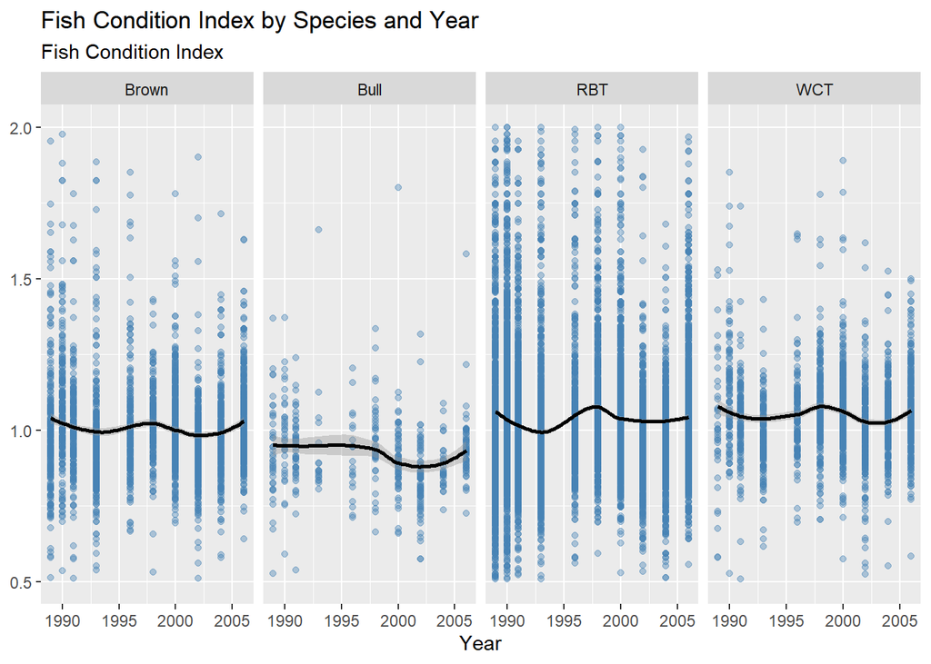

```r
bf_fish$condition <- fish_condition(length_col = bf_fish$length,
                                    weight_col = bf_fish$weight)

bf_fish |>
  ggplot(mapping = aes(x = year, y = condition)) +
  geom_point(color = 'steelblue', alpha = 0.4) +
  geom_smooth(method = 'loess', color = 'black') +
  scale_y_continuous(limits = c(0.5,2)) +
  facet_grid(~ species) +
  labs(x = "Year",
       y = NULL,
       title = "Fish Condition Index by Species and Year",
       subtitle = "Fish Condition Index")
```